# Random Number Generation and Reproducibility

## Random Number Generation and Reproducibility in R

Reproducibility is a cornerstone of scientific computing. When your analysis includes any random elements, understanding how R’s random number generation works is essential.

### How Random Number Generation Works in R

R uses what’s called a “pseudo-random number generator” (PRNG). This algorithm produces a sequence of numbers that appear random but are actually deterministic when you know the starting point, called a “seed”.

```r
# Without setting a seed, results will be different each time you run this code
sample(1:10, 5)
```

```
[1]  9 10  5  3  2
```

### Understanding set.seed()

The `set.seed()` function initializes R’s random number generator to a specific starting point:

```r
# Set the random seed
set.seed(123)
# Generate random sample
sample(1:10, 5)
```

```
[1]  3 10  2  8  6
```

**Important**: Each random function call advances the random number generator to its next state. Running the same function again produces different results:

```r
# Set the seed once
set.seed(123)

# First call to sample() after setting seed
result1 <- sample(1:10, 5)
print(result1)
```

```
[1]  3 10  2  8  6
```

```r
# Second call - different result!
result2 <- sample(1:10, 5)
print(result2)
```

```
[1] 5 4 6 8 1
```

```r
# Third call - yet another different result
result3 <- sample(1:10, 5)
print(result3)
```

```
[1] 10  5  3  8  1
```

### For True Reproducibility

If you need the exact same random numbers repeatedly, you have two options:

#### Option 1: Reset the seed before each random operation

```r
# Reset seed before each call
set.seed(123)
result1 <- sample(1:10, 5)

set.seed(123)
result2 <- sample(1:10, 5)

# These will be identical
identical(result1, result2)
```

```
[1] TRUE
```

#### Option 2: Store the results for reuse

```r
# Set seed once at the beginning of your analysis
set.seed(42)

# Generate and store the random values you need
random_sample <- sample(1:100, 10)
training_indices <- sample(1:nrow(mtcars), 20)

# Now use these stored values throughout your analysis
head(random_sample)
```

```
[1]  49  65  25  74  18 100
```

```r
head(mtcars[training_indices, ])
```

|  | mpg | cyl | disp | hp | drat | wt | qsec | vs | am | gear | carb |
| --- | --- | --- | --- | --- | --- | --- | --- | --- | --- | --- | --- |
| Hornet Sportabout | 18.7 | 8 | 360.0 | 175 | 3.15 | 3.440 | 17.02 | 0 | 0 | 3 | 2 |
| Merc 450SLC | 15.2 | 8 | 275.8 | 180 | 3.07 | 3.780 | 18.00 | 0 | 0 | 3 | 3 |
| Toyota Corolla | 33.9 | 4 | 71.1 | 65 | 4.22 | 1.835 | 19.90 | 1 | 1 | 4 | 1 |
| Fiat X1-9 | 27.3 | 4 | 79.0 | 66 | 4.08 | 1.935 | 18.90 | 1 | 1 | 4 | 1 |
| Fiat 128 | 32.4 | 4 | 78.7 | 66 | 4.08 | 2.200 | 19.47 | 1 | 1 | 4 | 1 |
| Cadillac Fleetwood | 10.4 | 8 | 472.0 | 205 | 2.93 | 5.250 | 17.98 | 0 | 0 | 3 | 4 |

### When to Use set.seed()

1. **Data splitting**: When creating training/testing splits for models

```r
   set.seed(123)
   train_indices <- sample(1:150, 100)
   iris_train <- iris[train_indices, ]
   iris_test <- iris[-train_indices, ]
```

2. **Simulations and bootstrap**: For consistent results

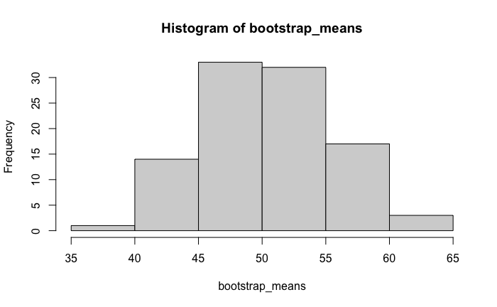

```r
   set.seed(123)
   bootstrap_means <- replicate(100, mean(sample(1:100, 30, replace = TRUE)))
   hist(bootstrap_means)
```

3. **Model fitting** with random components

```r
# Models like random forests have randomness in their algorithm
library(randomForest)  # Need to load the package first
set.seed(123)
model <- randomForest(Species ~ ., data = iris)
```

### Best Practices

1. **Document your seed**: Always note which seed you used in your documentation
2. **Set seed at analysis start**: For overall reproducibility of an entire notebook
3. **Reset seed at critical points**: When specific results must be identical
4. **Use different seeds**: For sensitivity analysis to ensure results aren’t seed-dependent

Remember: The specific seed value (like 123 or 42) doesn’t matter - what matters is using the same value when you want to reproduce results.